# Genome Wide Association Studies (GWAS)

Luis Felipe Ventorim Ferrão

Instructors - Patricio Munoz, Marcio Resende, Kevin Folta

# 1 Introduction

This tutorial aims to present basic concepts underlying the use of statistical genetic methods in genetic association studies. For this purpose, we will review the frequently used single-marker regression models and discuss the importance to account for population structure in GWAS models. All functions used in this hands-on are native from the `R` software (`lm` funtion, for example, is used to fit linear models). The dataset considered is freely available in the `BGLR` package (de Los Campos and Perez, 2016).

## 1.1 Dataset description

Information from a collection of 599 historical CIMMYT wheat lines. The wheat data set is from CIMMYT’s Global Wheat Program. Historically, this program has conducted numerous international trials across a wide variety of wheat-producing environments. The environments represented in these trials were grouped into four basic target sets of environments comprising four main agroclimatic regions previously defined and widely used by CIMMYT’s Global Wheat Breeding Program. The phenotypic trait considered here was the average grain yield (GY) of the 599 wheat lines evaluated in each of these four mega-environments (de Los Campos and Perez, 2016).

```r
library(BGLR)
data(wheat)
head(wheat.Y) #phenotypic data (ind x env)
```

```
##               1           2           4          5
## 775   1.6716295 -1.72746986 -1.89028479  0.0509159
## 2166 -0.2527028  0.40952243  0.30938553 -1.7387588
## 2167  0.3418151 -0.64862633 -0.79955921 -1.0535691
## 2465  0.7854395  0.09394919  0.57046773  0.5517574
## 3881  0.9983176 -0.28248062  1.61868192 -0.1142848
## 3889  2.3360969  0.62647587  0.07353311  0.7195856
```

```r
wheat.X[1:5,1:5] # genotypic data (ind x marker)
```

```
##      wPt.0538 wPt.8463 wPt.6348 wPt.9992 wPt.2838
## [1,]        0        1        1        1        1
## [2,]        1        1        1        1        1
## [3,]        1        1        1        1        1
## [4,]        0        1        1        1        1
## [5,]        0        1        1        1        1
```

```r
wheat.A[1:5,1:5] # pedigree (ind x ind)
```

```
##         775   2166   2167   2465   3881
## 775  1.9698 0.5742 0.5742 0.7236 1.0578
## 2166 0.5742 1.9930 1.9930 0.6724 0.4116
## 2167 0.5742 1.9930 1.9966 0.6724 0.4116
## 2465 0.7236 0.6724 0.6724 1.9970 0.5090
## 3881 1.0578 0.4116 0.4116 0.5090 1.9928
```

# 2 Single Marker Regression

Single-marker regression fit one SNP at a time. When assuming a single SNP *j* with genotypes coded as the number of copies of the allele with the minor frequency at the SNP for each individual *i* ($x_{ij} = \{0, 1 ,2\}$), the following model is frequently used:

$$y_i= \mu + \sum^p_{j=1} x_{ij}\beta_j + e_i$$

- $y_i$= phenotype
- $\mu$ = an effect common to all individuals (intercept)
- $x_{ij}$ = covariates (marker genotypes)
- $\beta_j$ = effetc of the $j^{th}$ covariate
- $e_i$ = model residual

In a matrix notation, model and the ordinary least squares estimate can be represented:

$$y = X\beta + e$$

$$[X'X]\hat{\beta}_{OLS} = X'y$$

## 2.1 Multiple Comparison

In GWAS analysis, there is the challenge of how best to control the type I error rate (or false positive rate). With single marker regression, a separate hypothesis test is performed for each marker locus. It is from this test that the statistical significance of a fixed marker effect is obtained. However, the resulting p values do not take into account that multiple tests are being performed. If the p values are not adjusted correctly for multiple testing, the type I error rate becomes inflated. In the literature, different methods are discussed to control for multiple tests. As discussed during the QTL class, empirical thresholds calculated with permutation are the gold standard in QTL mapping studies.

Bonferroni is another well-known approach for correcting for multiple testing. It is a popular method given the straightforward computational implementation. The difficulty is that correction is conservative when tests are dependent, as is the case in genome-wide studies. The Bonferroni correction compensates for that increase by testing each individual hypothesis at a significance level of $\alpha/m$, where $\alpha$ is the desired overall significance level (usually, 0.05) and $m$ is the number of hypotheses (in a GWAS, the number of marker).

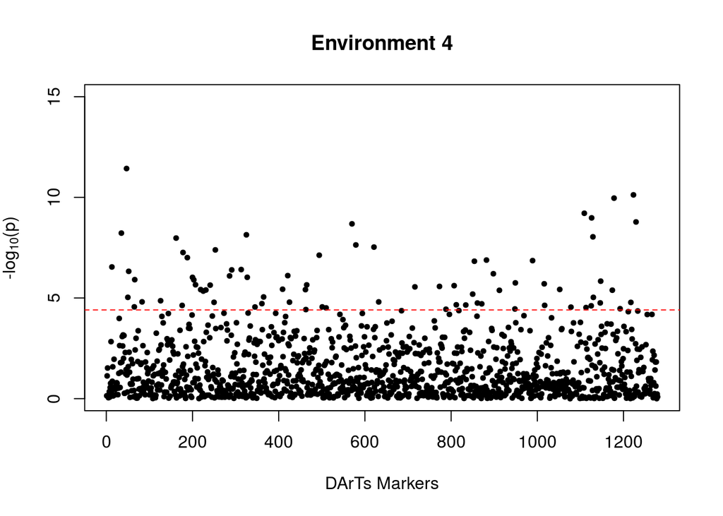

```r
# Single Marker regression - Env 4
X<-scale(wheat.X) # Molecular data
Y = wheat.Y[,4] # Env 4
p.value = vector()
  # GWAS (lm)
  for (i in 1:ncol(X)){
    #print(paste0("Marker ----> ", i))
    regression = (lm(Y~X[,i]))
    p.value[i] = summary(regression)$coef[2,4]
  }

# Bonferroni (0.05/m)
bonferroni = 0.05/ncol(X)

# Manhattan plot
  plot(-log(p.value,base=10), pch =19, cex = 0.6,
       ylab = expression(paste("-log"[10], "(p)", sep = "")),
       xlab = "DArTs Markers",
       main = "Environment 4",
        ylim=c(0,15)
      )
  abline(h= -log(bonferroni,base=10),col="red", lty=2)
```

```r
  which(p.value<bonferroni) # Markers significant p-values
```

```
##  [1]   13   35   47   50   52   65   66   83  126  162  176  178  188  200
## [15]  203  207  219  225  231  241  250  253  286  291  313  325  327  345
## [29]  361  365  409  421  425  462  463  465  494  501  510  570  579  621
## [43]  632  716  773  788  807  812  834  850  854  861  871  882  898  912
## [57]  948  949  989 1016 1017 1052 1078 1109 1113 1125 1126 1129 1130 1146
## [71] 1147 1174 1178 1192 1217 1223 1229
```

# 3 Single Marker Regression + Population Structure

Association studies in plants often involve data collected from highly structured populations. Population structure can cause spurious marker-trait associations. An expantion of the previos models includes a fixed effect to account for population structure. In a matrix notation, the model can write as:

$$y = X \beta + Xv + e$$

- y = vector of observed phenotypes.
- e = vector of residuals ($e \sim N(0,I \sigma^2_e)$)
- $\beta$ = vector of SNP effect
- v = vector of effects for the subpopulations (PCA analysis)

Different approaches to address population stratification in GWAS analysis can be considered. The Bayesian clustering implemented in the [STRUCTURE software](https://web.stanford.edu/group/pritchardlab/structure.html), discriminant analysis and principal component analysis (PCA) are widely appreciated in the literature. The `R` package [adegenet](https://cran.r-project.org/web/packages/adegenet/adegenet.pdf) have implemented the last two approaches. In this tutorial, we are highlighting the PCA analysis followed by a k-means clustering. On the [HOS 6236 webpage](https://hos6236.github.io/2017/09/26/GWAS.html) we posted an intuitive explanation about this methodology.

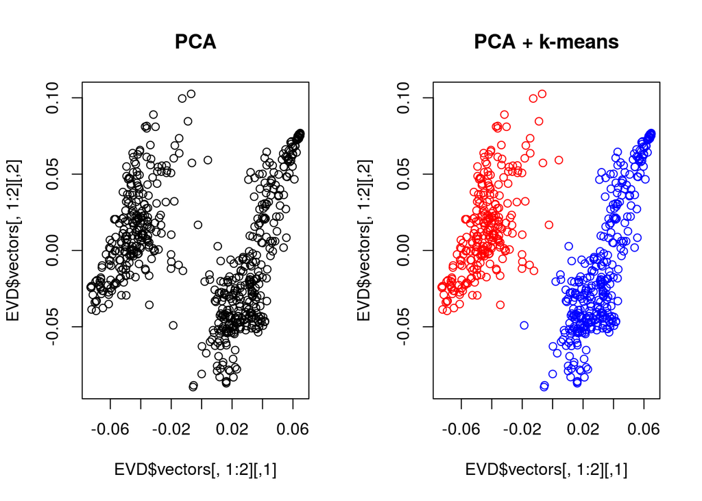

```r
# Original data set
X<-scale(wheat.X) # Molecular data
G<-tcrossprod(X) # Gmatrix

# PCA
par(mfrow=c(1,2))
EVD<-eigen(G) # PCA
plot(EVD$vectors[,1:2],main="PCA")

# K-means (2 groups)
set.seed(1)
new_df = cbind(EVD$vectors[,1],EVD$vectors[,2])
fit = kmeans(new_df,2)
color = ifelse(fit$cluster==1,"blue","red")
plot(EVD$vectors[,1:2],col=color,main="PCA + k-means")
```

The PCA analysis and the k-means clustering showed a stratification of two groups in the population. This information was added as fixed effect (`pop.cofactor`) in the previous single marker regression model (`lm` function).

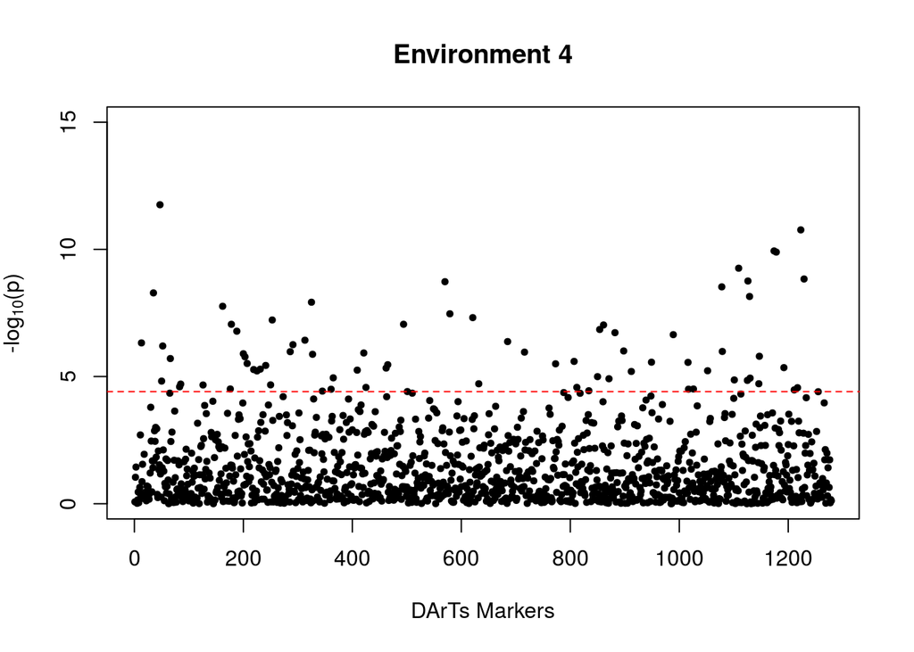

```r
## Correction for population structure (PCA)
pop.cofactor = factor(fit$cluster)
p.value = vector()
  # GWAS (lm)
  for (i in 1:ncol(X)){
    #print(paste0("Marker ----> ", i))
    regression = (lm(Y~pop.cofactor+X[,i]))
    p.value[i] = summary(regression)$coef[3,4]
  }


  bonferroni = 0.05/ncol(X)
  plot(-log(p.value,base=10), pch =19, cex = 0.6,
       ylab = expression(paste("-log"[10], "(p)", sep = "")),
       xlab = "DArTs Markers",
       main = "Environment 4",
       ylim=c(0,15)
  )
  abline(h= -log(bonferroni,base=10),col="red", lty=2)
```

## 3.1 Significant associations

When accounting for population structure in GWAS models it is possible to observe a change in the results. For example, the marker `510` was considered significant in the first analysis (without population structure), while in the second model no. Below it is possible to note the significant markers.

```r
# Markers significant p-values
which(p.value<bonferroni)
```

```
##  [1]   13   35   47   50   52   66   83   85  126  162  176  178  188  200
## [15]  203  207  219  225  231  241  250  253  286  291  313  325  327  345
## [29]  361  365  409  421  425  462  465  494  501  570  579  621  632  685
## [43]  716  773  807  812  834  850  854  861  871  882  898  912  949  989
## [57] 1016 1017 1026 1052 1078 1079 1101 1109 1125 1126 1129 1130 1146 1147
## [71] 1174 1178 1192 1211 1217 1223 1229
```

We can access the significant markers (p.value $<$ bonferroni threshold) and visualize the differences at the phenotypic level, as suggested in the QTL analysis. Markers `13`and `35` showed significant p-values, whereas marker `1`, for example, did not. The `boxplot` can be used to explain these differences in terms of average grain yield.

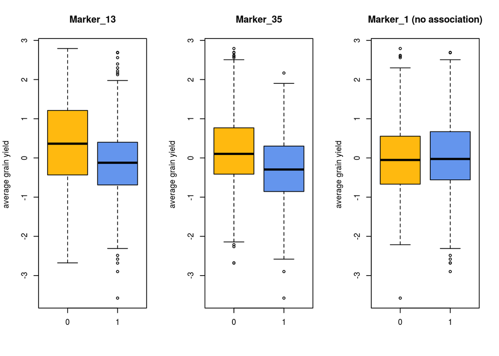

```r
par(mfrow=c(1,3))
boxplot(Y ~ wheat.X[, 13], main = "Marker_13", col = c("darkgoldenrod1", "cornflowerblue"),ylab= "average grain yield ")
boxplot(Y ~ wheat.X[, 35], main = "Marker_35", col = c("darkgoldenrod1", "cornflowerblue"),ylab= "average grain yield ")
boxplot(Y ~ wheat.X[, 1], main = "Marker_1 (no association)", col = c("darkgoldenrod1", "cornflowerblue"),ylab= "average grain yield ")
```

# 4 Citation

- Gustavo de los Campos and Paulino Perez Rodriguez, (2016). BGLR: Bayesian Generalized Linear Regression. R package version 1.0.5. https://CRAN.R-project.org/package=BGLR.